# Reproducible Research Project 1

Antoinette Mills

March 6, 2016

Requirement 1 - Code for reading in the data set and/or processing the data: Show any code that is needed to

```
Load the data (i.e. read.csv())
Process/transform the data (if necessary) into a format suitable for your analysis
```

```r
# Load the data file
MyData <- read.csv("activity.csv", as.is = TRUE)

# Remove the NA values and store in created subset object
GoodActivityData <- MyData[complete.cases(MyData), ]
```

Requirement 2 - What is mean total number of steps taken per day?

Step 1: Calculate the total number of steps taken per day

```r
#Calculate total number of steps taken per day
TotalStepsPerDay <- aggregate(steps ~ date, GoodActivityData, sum)
```

Step2: Make a histogram of the total number of steps taken each day

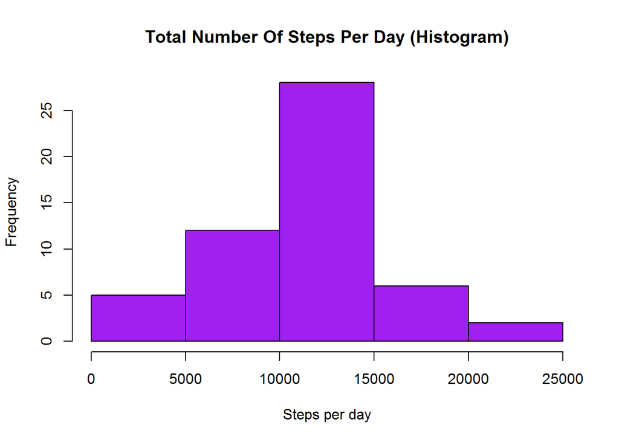

Step3: Calculate and report the mean and median of the total number of steps taken per day

```r
#Calculate mean
MeanOfSteps<-mean(TotalStepsPerDay$steps)
print(paste("The Mean of the total number of steps per day is ",MeanOfSteps))
```

```
## [1] "The Mean of the total number of steps per day is  10766.1886792453"
```

```r
#Calculate median
MedianOfSteps<-median(TotalStepsPerDay$steps)
print(paste("The Median of the total number of steps per day is ",MedianOfSteps))
```

```
## [1] "The Median of the total number of steps per day is  10765"
```

Requirement 3 - What is the average daily activity pattern?

Step 1: Make a time series plot (i.e. type = “l”) of the 5-minute interval (x-axis) and the average number of steps taken, averaged across all days (y-axis)

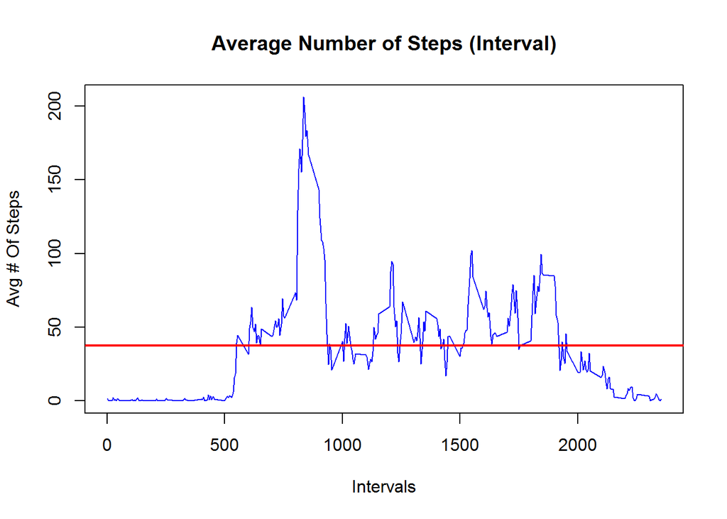

Step2: Which 5-minute interval, on average across all the days in the dataset, contains the maximum number of steps?

```
##     interval    steps
## 104      835 206.1698
```

Interval at 835 (8:35) with a value of 206.2 steps

Requirement 4 - Imputing missing values

Step 1: Calculate and report the total number of missing values in the dataset (i.e. the total number of rows with NAs)

```r
# Calculate and report the total number of missing values in the dataset (i.e. the total number of rows with NAs)
MissingValue <- MyData[!complete.cases(MyData), ]
print (paste("The number of rows with missing values is ",nrow(MissingValue)))
```

```
## [1] "The number of rows with missing values is  2304"
```

Step 2 & 3:

```r
for (i in 1:nrow(MyData)) {
        if(is.na(MyData$steps[i])) {
                val <- AvgStepsAllDays$steps[which(AvgStepsAllDays$interval == MyData$interval[i])]
                MyData$steps[i] <- val
        }
}
```

Step 4: Make a histogram of the total number of steps taken each day and Calculate and report the mean and median total number of steps taken per day.

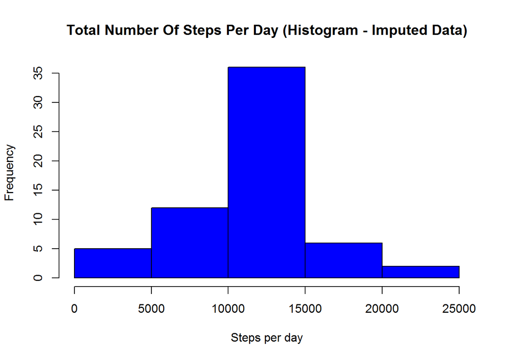

```r
#Calculate total number of steps taken per day with imputed Data
TotalStepsPerDay_imputed <- aggregate(steps ~ date, MyData, sum)

#Histogram of number of steps per day with imputed Data
hist(TotalStepsPerDay_imputed$steps, main = "Total Number Of Steps Per Day (Histogram - Imputed Data)", xlab = "Steps per day", col="blue")
```

```r
#Calculate mean of imputed data
MeanOfSteps_imputed<-mean(TotalStepsPerDay_imputed$steps)
print(paste("The Mean of the total number of steps per day is ",MeanOfSteps_imputed))
```

```
## [1] "The Mean of the total number of steps per day is  10766.1886792453"
```

```r
#Calculate median of imputed data
MedianOfSteps_imputed<-median(TotalStepsPerDay_imputed$steps)
print(paste("The Median of the total number of steps per day is ",MedianOfSteps_imputed))
```

```
## [1] "The Median of the total number of steps per day is  10766.1886792453"
```

Both the Median and the Mean have not significantly changed. Now let’s examine impact on estimates of total daily number of steps:

```r
#What is the impact of imputing missing data on the estimates of the total daily number of steps?
MyDifference<-sum(MyData$steps)-sum(GoodActivityData$steps)
MyDifference
```

```
## [1] 86129.51
```

There was a significant impact on the estimation of total steps per day (increase).

Requirement 5: Are there differences in activity patterns between weekdays and weekends?

Step 1: Create a new factor variable in the dataset with two levels - “weekday” and “weekend” indicating whether a given date is a weekday or weekend day.

```r
WeekDay <- function(date_val) {
        WdDate <- weekdays(as.Date(date_val, '%Y-%m-%d'))
        if  (!(WdDate == 'Saturday' || WdDate == 'Sunday')) {
                testData <- 'Weekday'
        } else {
                testData <- 'Weekend'
        }
        testData
}
```

Step 2: Make a panel plot containing a time series plot (i.e. type = “l”) of the 5-minute interval (x-axis) and the average number of steps taken, averaged across all weekday days or weekend days (y-axis).

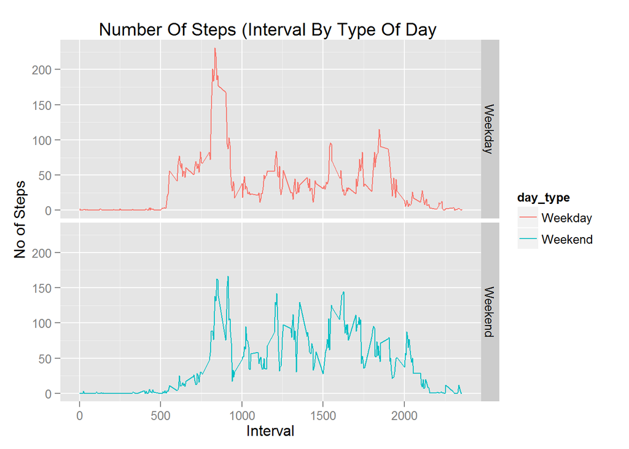

```r
print(myplot)
```